# DATA 621 Homework 1

Ilya Kats

## Data Exploration

The data set describes baseball team statistics for the years 1871 to 2006 inclusive. Each record in the data set represents the performance of the team for the given year adjusted to the current length of the season - 162 games. The data set includes 16 variables and the training set includes 2,276 records.

Each variable is presented below with corresponding basic statistics (minimum, median and maximum values, mean and standard deviation, number of records with missing values and zero values), boxplot, density plot with highlighted mean value, and scatterplot against outcome variable (`TARGET_WINS`) with best fit line. This information is used to check general validity of data and adjust as necessary.

#### TEAM_BATTING_H: Number of team base hits (includes singles, doubles, triples and home runs)

| Min | Median | Mean | SD | Max | Num of NAs | Num of Zeros |
| --- | --- | --- | --- | --- | --- | --- |
| 891 | 1454 | 1469.27 | 144.5912 | 2554 | 0 | 0 |

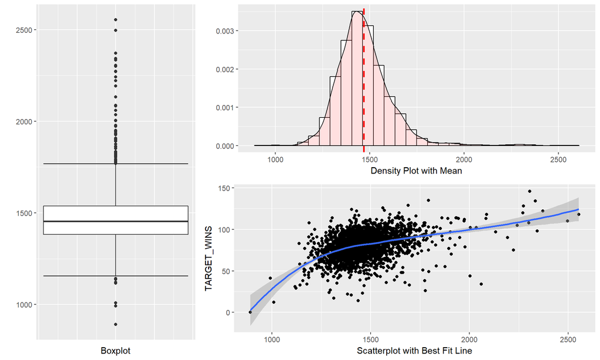

**Analysis:** There are no missing values. The range and distribution are reasonable.

#### TEAM_BATTING_2B: Number of team doubles

| Min | Median | Mean | SD | Max | Num of NAs | Num of Zeros |
| --- | --- | --- | --- | --- | --- | --- |
| 69 | 238 | 241.2469 | 46.80141 | 458 | 0 | 0 |

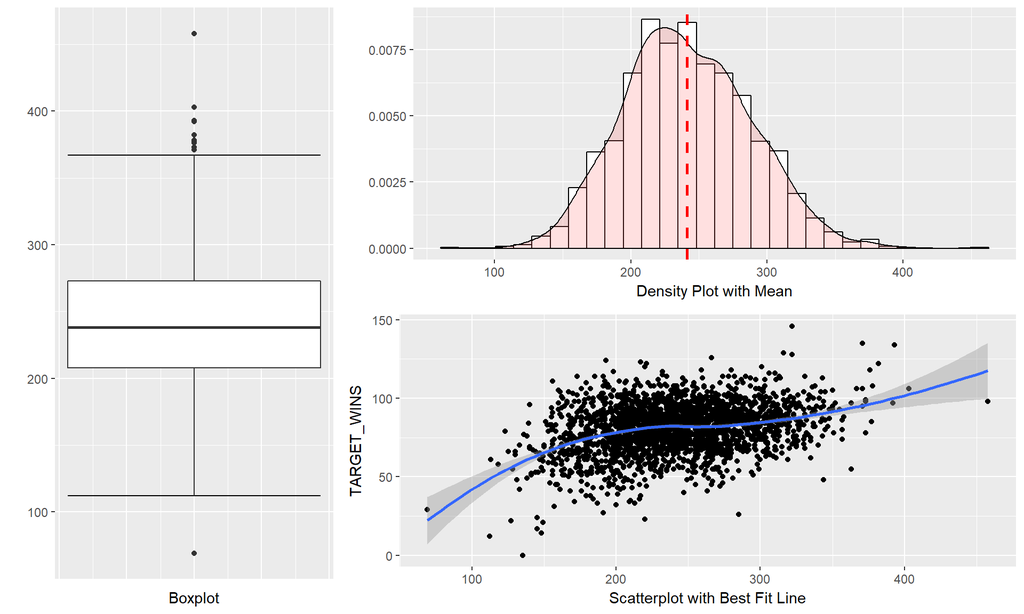

**Analysis:** There are no missing values. The range and distribution are reasonable.

#### TEAM_BATTING_3B: Number of team triples

| Min | Median | Mean | SD | Max | Num of NAs | Num of Zeros |
| --- | --- | --- | --- | --- | --- | --- |
| 0 | 47 | 55.25 | 27.93856 | 223 | 0 | 2 |

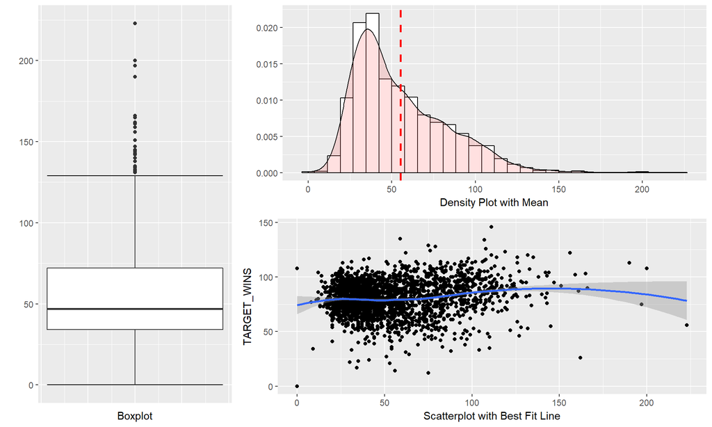

**Analysis:** The range and distribution are reasonable. There are 2 records with zero values which is unrealistic for a team in a season. One record (index 1347) has 12 variables with missing values, including the outcome variable. This record will be deleted from the data set. Second record (index 1494) has 7 missing variables, but it does have some recorded values in all categories - batting, pitching and fielding. Zero value for `TEAM_BATTING_3B` can be replaced with the median (because the distribution is right-skewed, median value will provide more realistic estimate).

#### TEAM_BATTING_HR: Number of team home runs

| Min | Median | Mean | SD | Max | Num of NAs | Num of Zeros |
| --- | --- | --- | --- | --- | --- | --- |
| 0 | 102 | 99.61204 | 60.54687 | 264 | 0 | 15 |

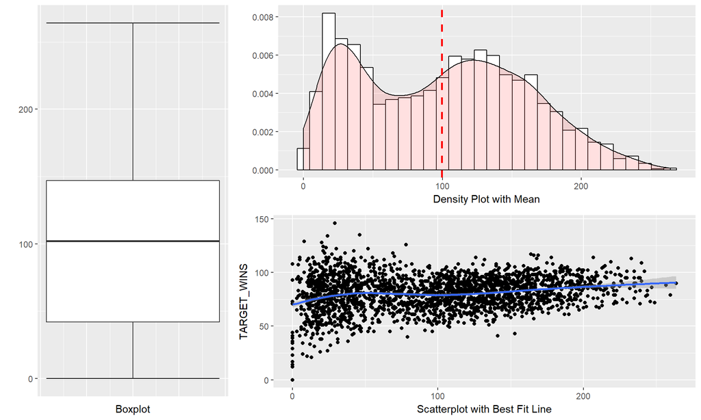

**Analysis:** The range is reasonable. The distribution is interesting because it is multimodal. Most likely this indicates major changes in game dynamics - perhaps, some rule adjustments started favoring batters. Or perhaps, this is an affect of steroid era. There are 15 records with zero values which is unrealistic for this variable. They can be imputed from other values.

#### TEAM_BATTING_BB: Number of team walks

| Min | Median | Mean | SD | Max | Num of NAs | Num of Zeros |
| --- | --- | --- | --- | --- | --- | --- |
| 0 | 512 | 501.5589 | 122.6709 | 878 | 0 | 1 |

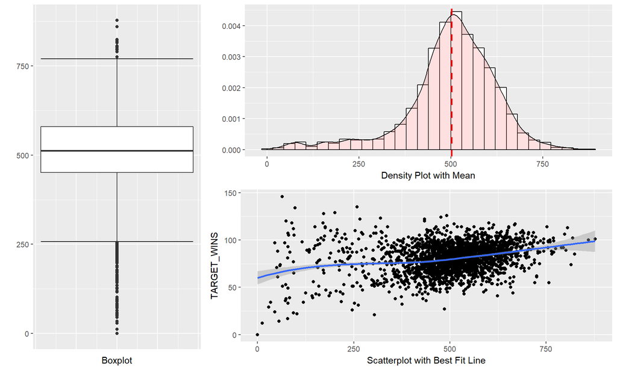

**Analysis:** The range and distribution are reasonable. There is one record (index 1347) that has a zero value. This record was discussed above (under `TEAM_BATTING_3B`) and it will be deleted from the data set.

#### TEAM_BATTING_HBP: Number of team batters hit by pitch

| Min | Median | Mean | SD | Max | Num of NAs | Num of Zeros |
| --- | --- | --- | --- | --- | --- | --- |
| 29 | 58 | 59.35602 | 12.96712 | 95 | 2085 | 0 |

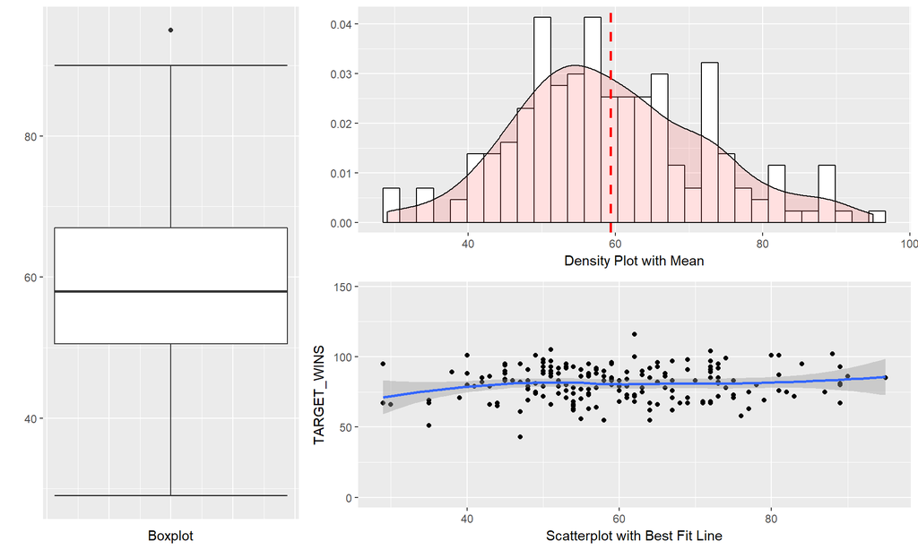

**Analysis:** There are 2,085 records - 91.6% of data set - that are missing value. Because this variable is missing for majority of records, it will not be imputed and will be left out from the regression model.

#### TEAM_BATTING_SO: Number of team strikeouts by batters

| Min | Median | Mean | SD | Max | Num of NAs | Num of Zeros |
| --- | --- | --- | --- | --- | --- | --- |
| 0 | 750 | 735.6053 | 248.5264 | 1399 | 102 | 20 |

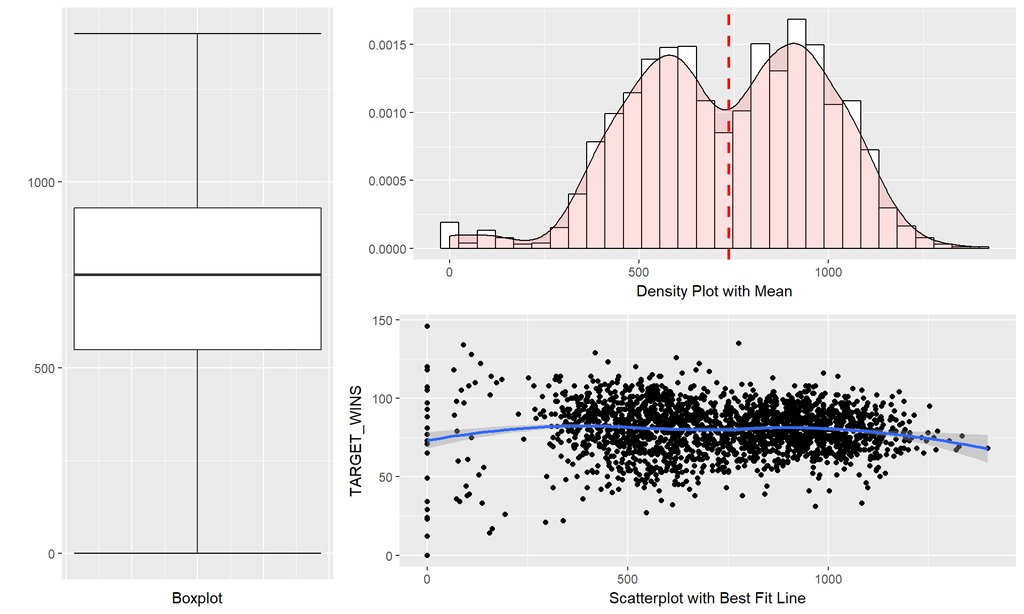

**Analysis:** There are 122 records with missing or zero value (as wtih other variables a zero value is unrealistic). These values can be imputed. Similarly to homeruns, the distribution is multimodal, which is interesting enough for additional analysis. Another area of concern is a noticeable left tail. It is highly unlikely to have games without any strikeouts, so anything lower than 162 (average of 1 strikeout per game) is definitely suspect.

#### TEAM_BASERUN_SB: Number of team stolen bases

| Min | Median | Mean | SD | Max | Num of NAs | Num of Zeros |
| --- | --- | --- | --- | --- | --- | --- |
| 0 | 101 | 124.7618 | 87.79117 | 697 | 131 | 2 |

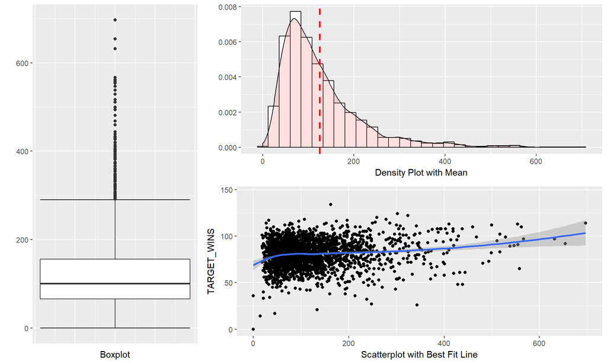

**Analysis:** The range and distribution are reasonable. The only issue are 133 records with missing or zero value. These values can be imputed in order to use these records in model building.

#### TEAM_BASERUN_CS: Number of team runners caught stealing

| Min | Median | Mean | SD | Max | Num of NAs | Num of Zeros |
| --- | --- | --- | --- | --- | --- | --- |
| 0 | 49 | 52.80386 | 22.95634 | 201 | 772 | 1 |

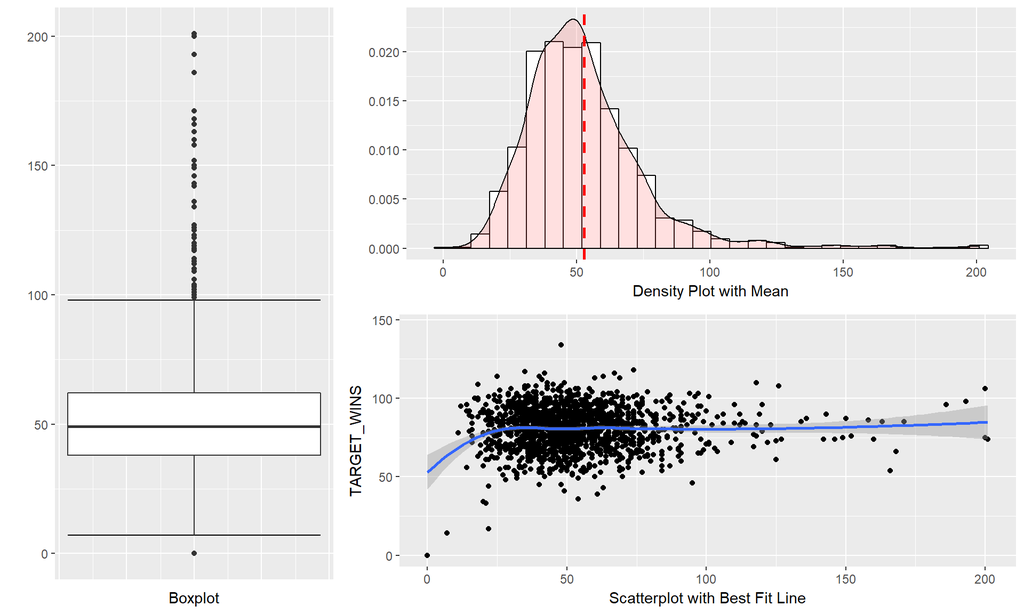

**Analysis:** The range and distribution are reasonable; however, there is significant number of missing values - 773, including one zero value. This represents a third of the entire data set. It may be possible to impute this value, but it may be necessary to leave this variable out of model building.

#### TEAM_FIELDING_E: Number of team fielding errors

| Min | Median | Mean | SD | Max | Num of NAs | Num of Zeros |
| --- | --- | --- | --- | --- | --- | --- |
| 65 | 159 | 246.4807 | 227.771 | 1898 | 0 | 0 |

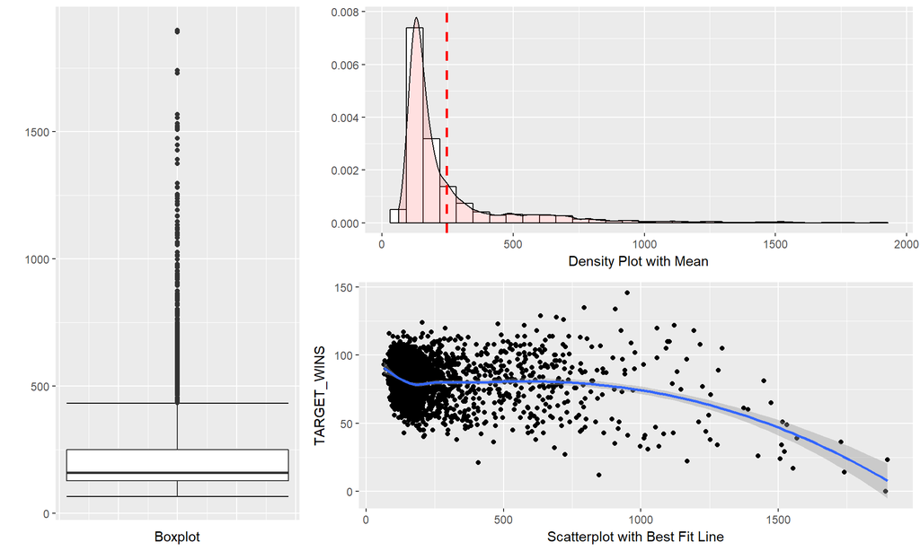

**Analysis:** There are no missing values. Distribution has a very long right tail. Values in the 1,000 and above range are highly suspect. One of the highest historical number of errors is 867 errors by Washington in 1886 for 122 games. That is equal about 1,151 errors for 162 game season. There are multiple values above that number. This may unfavorably influence a model.

#### TEAM_FIELDING_DP: Number of team fielding double plays

| Min | Median | Mean | SD | Max | Num of NAs | Num of Zeros |
| --- | --- | --- | --- | --- | --- | --- |
| 52 | 149 | 146.3879 | 26.22639 | 228 | 286 | 0 |

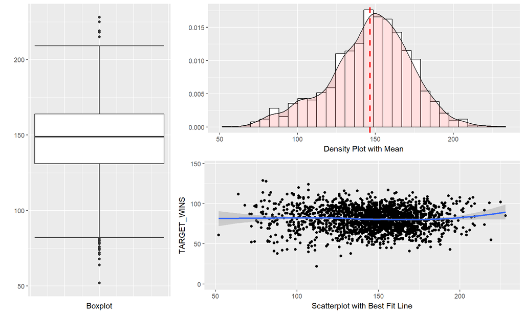

**Analysis:** The range and distribution are reasonable. Similar to a few other variables there is a medium number off missing values - 286 records. This value can be imputed.

#### TEAM_PITCHING_BB: Number of walks given up by pitchers

| Min | Median | Mean | SD | Max | Num of NAs | Num of Zeros |
| --- | --- | --- | --- | --- | --- | --- |
| 0 | 536.5 | 553.0079 | 166.3574 | 3645 | 0 | 1 |

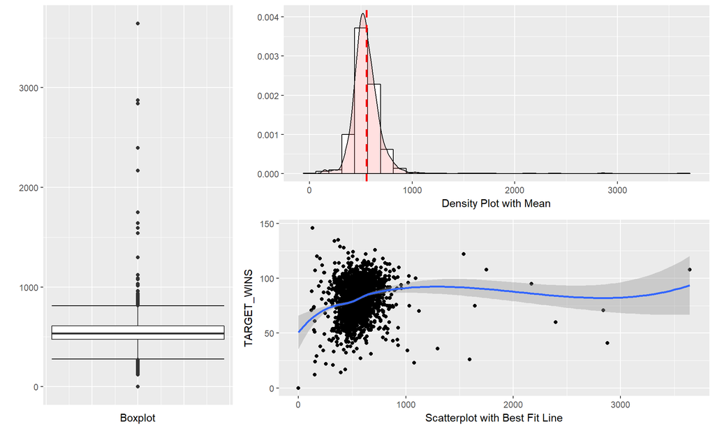

**Analysis:** There are no missing values with the exception of record 1347 which will be deleted from model building. There are some unrealistic outliers. Current record of walks by a team in a season is held by 1949 Boston Red Sox - 835 walks in 155 games. For a 162 game season, this number is 873. This variable will be capped at 1,100 and any value over this will be set to this cap.

#### TEAM_PITCHING_H: Number of base hits given up by pitchers

| Min | Median | Mean | SD | Max | Num of NAs | Num of Zeros |
| --- | --- | --- | --- | --- | --- | --- |
| 1137 | 1518 | 1779.21 | 1406.843 | 30132 | 0 | 0 |

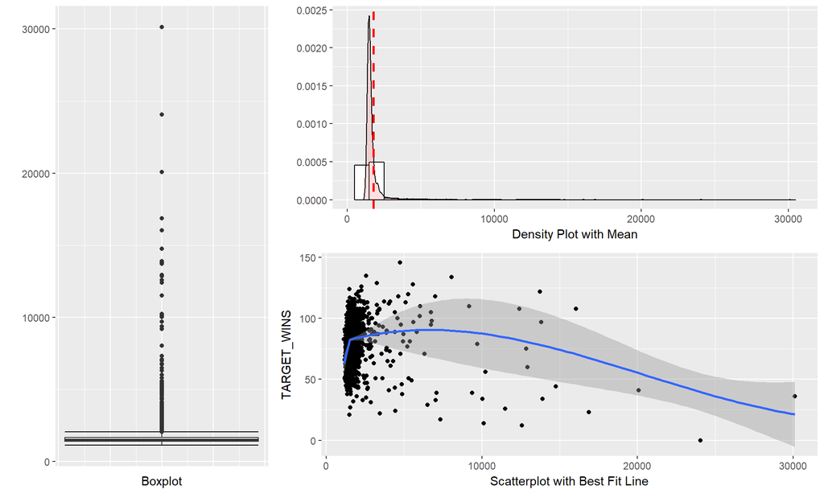

**Analysis:** Similar to `TEAM_PITCHING_BB` above, there are no missing value, but there issues with outliers. Based on visualizations, this variable will be capped at 13,000 and any value over this will be set to this cap.

#### TEAM_PITCHING_HR: Number of home runs given up by pitchers

| Min | Median | Mean | SD | Max | Num of NAs | Num of Zeros |
| --- | --- | --- | --- | --- | --- | --- |
| 0 | 107 | 105.6986 | 61.29875 | 343 | 0 | 15 |

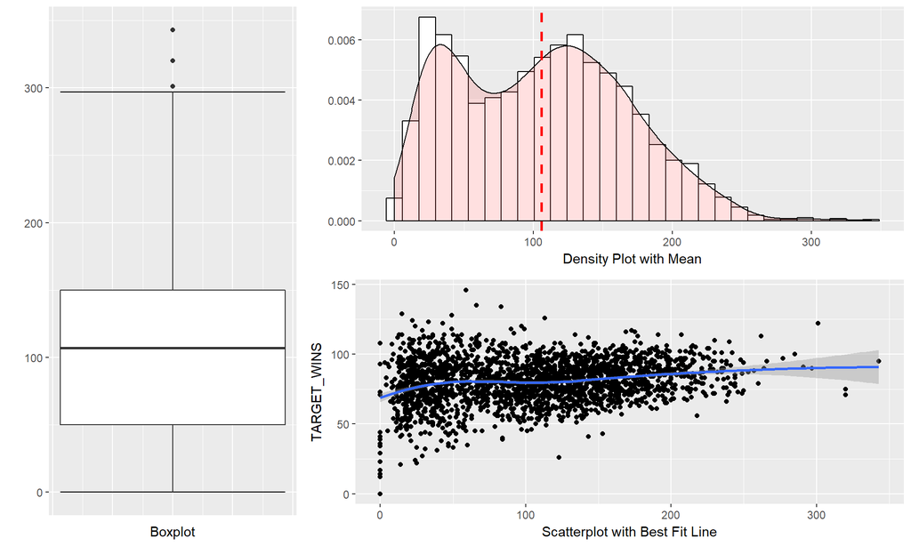

**Analysis:** This variable is more consistent than other pitching variables. The range and distribution are reasonable. Multimodality is interesting similar to a few other variables above. There are 15 zero values which can be imputed as needed.

#### TEAM_PITCHING_SO: Number of strikeouts by pitchers

| Min | Median | Mean | SD | Max | Num of NAs | Num of Zeros |
| --- | --- | --- | --- | --- | --- | --- |
| 0 | 813.5 | 817.7305 | 553.085 | 19278 | 102 | 20 |

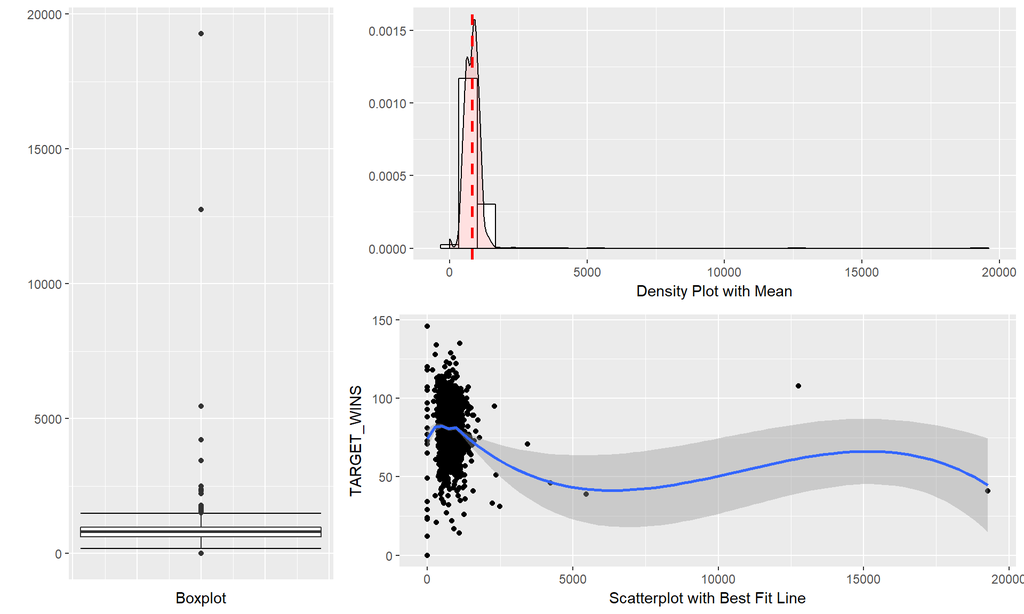

**Analysis:** This variable has 122 missing or zero values. They can be imputed as needed. There is also an outlier issue. Based on visualizations, this variable will be capped at 2,500 and any value over this will be set to this cap.

#### TARGET_WINS: Number of wins **(Outcome)**

| Min | Median | Mean | SD | Max | Num of NAs | Num of Zeros |
| --- | --- | --- | --- | --- | --- | --- |
| 0 | 82 | 80.79086 | 15.75215 | 146 | 0 | 1 |

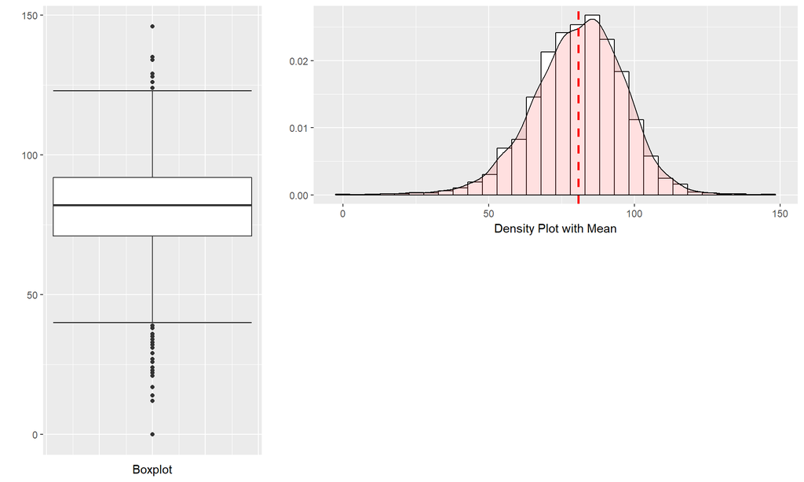

**Analysis:** The range and distribution are reasonable. There are no missing values with the exception of record 1347.

#### Correlation Matrix

|  | Wins | H | 2B | 3B | HR | BB | SO | SB | CS | HBP | P-H | P-HR | P-BB | P-SO | E | DP |
| --- | --- | --- | --- | --- | --- | --- | --- | --- | --- | --- | --- | --- | --- | --- | --- | --- |
| Wins | 1 | 0.39 | 0.29 | 0.14 | 0.18 | 0.23 | -0.03 | 0.14 | 0.02 | 0.07 | -0.11 | 0.19 | 0.12 | -0.08 | -0.18 | -0.03 |
| H | 0.39 | 1 | 0.56 | 0.43 | -0.01 | -0.07 | -0.46 | 0.12 | 0.02 | -0.03 | 0.3 | 0.07 | 0.09 | -0.25 | 0.26 | 0.16 |
| 2B | 0.29 | 0.56 | 1 | -0.11 | 0.44 | 0.26 | 0.16 | -0.2 | -0.1 | 0.05 | 0.02 | 0.45 | 0.18 | 0.06 | -0.24 | 0.29 |
| 3B | 0.14 | 0.43 | -0.11 | 1 | -0.64 | -0.29 | -0.67 | 0.53 | 0.35 | -0.17 | 0.19 | -0.57 | 0 | -0.26 | 0.51 | -0.32 |
| HR | 0.18 | -0.01 | 0.44 | -0.64 | 1 | 0.51 | 0.73 | -0.45 | -0.43 | 0.11 | -0.25 | 0.97 | 0.14 | 0.18 | -0.59 | 0.45 |
| BB | 0.23 | -0.07 | 0.26 | -0.29 | 0.51 | 1 | 0.38 | -0.11 | -0.14 | 0.05 | -0.45 | 0.46 | 0.49 | -0.02 | -0.66 | 0.43 |
| SO | -0.03 | -0.46 | 0.16 | -0.67 | 0.73 | 0.38 | 1 | -0.25 | -0.22 | 0.22 | -0.38 | 0.67 | 0.04 | 0.42 | -0.58 | 0.15 |
| SB | 0.14 | 0.12 | -0.2 | 0.53 | -0.45 | -0.11 | -0.25 | 1 | 0.66 | -0.06 | 0.07 | -0.42 | 0.15 | -0.14 | 0.51 | -0.5 |
| CS | 0.02 | 0.02 | -0.1 | 0.35 | -0.43 | -0.14 | -0.22 | 0.66 | 1 | -0.07 | -0.05 | -0.42 | -0.11 | -0.21 | 0.05 | -0.21 |
| HBP | 0.07 | -0.03 | 0.05 | -0.17 | 0.11 | 0.05 | 0.22 | -0.06 | -0.07 | 1 | -0.03 | 0.11 | 0.05 | 0.22 | 0.04 | -0.07 |
| P-H | -0.11 | 0.3 | 0.02 | 0.19 | -0.25 | -0.45 | -0.38 | 0.07 | -0.05 | -0.03 | 1 | -0.14 | 0.32 | 0.27 | 0.67 | -0.23 |
| P-HR | 0.19 | 0.07 | 0.45 | -0.57 | 0.97 | 0.46 | 0.67 | -0.42 | -0.42 | 0.11 | -0.14 | 1 | 0.22 | 0.21 | -0.49 | 0.44 |
| P-BB | 0.12 | 0.09 | 0.18 | 0 | 0.14 | 0.49 | 0.04 | 0.15 | -0.11 | 0.05 | 0.32 | 0.22 | 1 | 0.49 | -0.02 | 0.32 |
| P-SO | -0.08 | -0.25 | 0.06 | -0.26 | 0.18 | -0.02 | 0.42 | -0.14 | -0.21 | 0.22 | 0.27 | 0.21 | 0.49 | 1 | -0.02 | 0.03 |
| E | -0.18 | 0.26 | -0.24 | 0.51 | -0.59 | -0.66 | -0.58 | 0.51 | 0.05 | 0.04 | 0.67 | -0.49 | -0.02 | -0.02 | 1 | -0.5 |
| DP | -0.03 | 0.16 | 0.29 | -0.32 | 0.45 | 0.43 | 0.15 | -0.5 | -0.21 | -0.07 | -0.23 | 0.44 | 0.32 | 0.03 | -0.5 | 1 |

Anything over 0.5 or under -0.5 is highlighted in blue. The matrix was created using complete pairwise observations.

A few conclusions:

- Not surprisingly there is a very strong correlation between home runs batted in and home runs given up by pitching.
- There is a negative correlation between number of triples and home runs. A less powerful team may not have enough power to hit home runs, but they get a lot of triples.
- THere is a strong positive correlation between number of strikeouts and home runs. More swings of the bat results in more home runs.

## Data Preparation

As noted in the *Data Exploration* section, the following adjustments have been performed:

- Record 1347 having 0 for outcome variable `TARGET_WINS` has been removed.
- Variable `TEAM_BATTING_HBP` has been removed.
- Any zero value in all variables has been converted to `NA`.
- Any `NA` value has been imputed using `aregImpute` function of `Hmisc` R package. $R^2$ of imputations are as follows:

```
##  TEAM_BATTING_3B  TEAM_BATTING_HR  TEAM_BATTING_SO  TEAM_BASERUN_SB
##        0.7263637        0.9834393        0.9285304        0.7007561
##  TEAM_BASERUN_CS TEAM_FIELDING_DP TEAM_PITCHING_HR TEAM_PITCHING_SO
##        0.6088321        0.4922156        0.9822117        0.8206171
```

- Outliers for several variables have been capped: `TEAM_PITCHING_SO` at 2,500, `TEAM_PITCHING_H` at 13,000, and `TEAM_PITCHING_BB` at 1100.
- To even out the spread of `TEAM_FIELDING_E` which has a long right tail with low median value, it has been log-transformed.
- A new variable has been created to calculate number of singles batting in. It is equal to number of base hits minus doubles, triples and home runs.

## Model Building

### Model 1

The first model includes several variables, selected manually, that have higher than average correlation to the target variable. They cover hitting, walking and fielding errors.

```
##
## Call:
## lm(formula = TARGET_WINS ~ TEAM_BATTING_H + TEAM_BATTING_BB +
##     TEAM_FIELDING_E, data = bb)
##
## Residuals:
##     Min      1Q  Median      3Q     Max
## -50.971  -9.022   0.101   9.062  51.557
##
## Coefficients:
##                  Estimate Std. Error t value Pr(>|t|)
## (Intercept)      4.089556   3.311975   1.235    0.217
## TEAM_BATTING_H   0.049143   0.002100  23.403  < 2e-16 ***
## TEAM_BATTING_BB  0.016107   0.003136   5.137 3.03e-07 ***
## TEAM_FIELDING_E -0.014493   0.001768  -8.196 4.11e-16 ***
## ---
## Signif. codes:  0 '***' 0.001 '**' 0.01 '*' 0.05 '.' 0.1 ' ' 1
##
## Residual standard error: 13.7 on 2271 degrees of freedom
## Multiple R-squared:  0.2356, Adjusted R-squared:  0.2346
## F-statistic: 233.3 on 3 and 2271 DF,  p-value: < 2.2e-16
```

All variables are significant, but the $R^2$ value is relatively small at 0.2356.

### Model 2

The second model expand the base hit variable, `TEAM_BATTING_H`, into its components - singles, doubles, triples and home runs.

```
##
## Call:
## lm(formula = TARGET_WINS ~ TEAM_BATTING_S + TEAM_BATTING_2B +
##     TEAM_BATTING_3B + TEAM_BATTING_HR + TEAM_BATTING_BB + TEAM_FIELDING_E,
##     data = bb)
##
## Residuals:
##     Min      1Q  Median      3Q     Max
## -52.651  -8.783   0.091   8.752  57.268
##
## Coefficients:
##                  Estimate Std. Error t value Pr(>|t|)
## (Intercept)      8.294110   3.437023   2.413 0.015893 *
## TEAM_BATTING_S   0.045088   0.003148  14.325  < 2e-16 ***
## TEAM_BATTING_2B  0.021516   0.007410   2.904 0.003724 **
## TEAM_BATTING_3B  0.166209   0.015084  11.019  < 2e-16 ***
## TEAM_BATTING_HR  0.081628   0.007757  10.524  < 2e-16 ***
## TEAM_BATTING_BB  0.012264   0.003195   3.839 0.000127 ***
## TEAM_FIELDING_E -0.018467   0.001978  -9.336  < 2e-16 ***
## ---
## Signif. codes:  0 '***' 0.001 '**' 0.01 '*' 0.05 '.' 0.1 ' ' 1
##
## Residual standard error: 13.51 on 2268 degrees of freedom
## Multiple R-squared:  0.2582, Adjusted R-squared:  0.2562
## F-statistic: 131.6 on 6 and 2268 DF,  p-value: < 2.2e-16
```

### Model 3

The third model includes several variables manually selected to try and cover different aspects of the game:

- `TEAM_BATTING_SO:TEAM_BATTING_H` interaction covers offensive successes (hits) and failures (strikeouts).
- Similarly `TEAM_BATTING_BB:TEAM_BATTING_H` interaction covers interaction between hits and walks.
- `TEAM_BASERUN_SB` covers base running.
- `TEAM_FIELDING_DP` and `TEAM_FIELDING_E_LOG` cover fielding performance.
- `TEAM_PITCHING_HR` covers pitching performance.

```
##
## Call:
## lm(formula = TARGET_WINS ~ TEAM_BATTING_SO:TEAM_BATTING_H + TEAM_BATTING_BB:TEAM_BATTING_H +
##     TEAM_BATTING_SO + TEAM_BASERUN_SB + TEAM_FIELDING_DP + TEAM_PITCHING_HR +
##     TEAM_FIELDING_E_LOG, data = bb)
##
## Residuals:
##     Min      1Q  Median      3Q     Max
## -58.004  -8.314   0.056   8.359  60.396
##
## Coefficients:
##                                  Estimate Std. Error t value Pr(>|t|)
## (Intercept)                     1.781e+02  6.832e+00  26.065  < 2e-16 ***
## TEAM_BATTING_SO                -8.597e-02  5.601e-03 -15.350  < 2e-16 ***
## TEAM_BASERUN_SB                 5.582e-02  4.365e-03  12.789  < 2e-16 ***
## TEAM_FIELDING_DP               -1.381e-01  1.333e-02 -10.361  < 2e-16 ***
## TEAM_PITCHING_HR                5.278e-02  7.613e-03   6.933 5.35e-12 ***
## TEAM_FIELDING_E_LOG            -1.537e+01  9.350e-01 -16.437  < 2e-16 ***
## TEAM_BATTING_SO:TEAM_BATTING_H  4.378e-05  4.316e-06  10.146  < 2e-16 ***
## TEAM_BATTING_H:TEAM_BATTING_BB  8.939e-06  1.916e-06   4.666 3.26e-06 ***
## ---
## Signif. codes:  0 '***' 0.001 '**' 0.01 '*' 0.05 '.' 0.1 ' ' 1
##
## Residual standard error: 13.01 on 2267 degrees of freedom
## Multiple R-squared:  0.312,  Adjusted R-squared:  0.3099
## F-statistic: 146.9 on 7 and 2267 DF,  p-value: < 2.2e-16
```

### Model 4

```
##
## Call:
## lm(formula = TARGET_WINS ~ TEAM_BATTING_S + TEAM_BATTING_2B +
##     TEAM_BATTING_3B + TEAM_BATTING_HR + TEAM_BATTING_BB + TEAM_BATTING_SO +
##     TEAM_BASERUN_SB + TEAM_FIELDING_DP + TEAM_FIELDING_E + TEAM_PITCHING_BB +
##     TEAM_PITCHING_H + TEAM_PITCHING_SO + TEAM_PITCHING_HR, data = bb)
##
## Residuals:
##     Min      1Q  Median      3Q     Max
## -54.569  -8.363   0.155   8.083  50.081
##
## Coefficients:
##                    Estimate Std. Error t value Pr(>|t|)
## (Intercept)      32.6392961  5.1756323   6.306 3.43e-10 ***
## TEAM_BATTING_S    0.0435789  0.0036543  11.925  < 2e-16 ***
## TEAM_BATTING_2B   0.0197203  0.0070515   2.797  0.00521 **
## TEAM_BATTING_3B   0.0940512  0.0153017   6.146 9.34e-10 ***
## TEAM_BATTING_HR   0.1698008  0.0327441   5.186 2.34e-07 ***
## TEAM_BATTING_BB   0.0514871  0.0102384   5.029 5.32e-07 ***
## TEAM_BATTING_SO  -0.0362081  0.0045083  -8.031 1.53e-15 ***
## TEAM_BASERUN_SB   0.0516288  0.0042746  12.078  < 2e-16 ***
## TEAM_FIELDING_DP -0.1346286  0.0128015 -10.517  < 2e-16 ***
## TEAM_FIELDING_E  -0.0456375  0.0027964 -16.320  < 2e-16 ***
## TEAM_PITCHING_BB -0.0364057  0.0085819  -4.242 2.30e-05 ***
## TEAM_PITCHING_H   0.0029002  0.0005642   5.140 2.98e-07 ***
## TEAM_PITCHING_SO  0.0224493  0.0035101   6.396 1.94e-10 ***
## TEAM_PITCHING_HR -0.0436116  0.0296242  -1.472  0.14112
## ---
## Signif. codes:  0 '***' 0.001 '**' 0.01 '*' 0.05 '.' 0.1 ' ' 1
##
## Residual standard error: 12.49 on 2261 degrees of freedom
## Multiple R-squared:  0.3678, Adjusted R-squared:  0.3642
## F-statistic: 101.2 on 13 and 2261 DF,  p-value: < 2.2e-16
```

### Model 5

```
##
## Call:
## lm(formula = TARGET_WINS ~ TEAM_BATTING_S + TEAM_BATTING_3B +
##     TEAM_BATTING_HR + TEAM_BASERUN_SB + TEAM_FIELDING_E_LOG *
##     TEAM_PITCHING_H, data = bb)
##
## Residuals:
##     Min      1Q  Median      3Q     Max
## -46.883  -8.654  -0.053   8.525  51.760
##
## Coefficients:
##                                       Estimate Std. Error t value Pr(>|t|)
## (Intercept)                         45.0938220  8.2036546   5.497 4.30e-08
## TEAM_BATTING_S                       0.0472941  0.0030570  15.471  < 2e-16
## TEAM_BATTING_3B                      0.1568263  0.0152216  10.303  < 2e-16
## TEAM_BATTING_HR                      0.0760448  0.0071664  10.611  < 2e-16
## TEAM_BASERUN_SB                      0.0556409  0.0039068  14.242  < 2e-16
## TEAM_FIELDING_E_LOG                 -9.2040428  1.4206862  -6.479 1.13e-10
## TEAM_PITCHING_H                      0.0262235  0.0045303   5.789 8.08e-09
## TEAM_FIELDING_E_LOG:TEAM_PITCHING_H -0.0037734  0.0006403  -5.893 4.35e-09
##
## (Intercept)                         ***
## TEAM_BATTING_S                      ***
## TEAM_BATTING_3B                     ***
## TEAM_BATTING_HR                     ***
## TEAM_BASERUN_SB                     ***
## TEAM_FIELDING_E_LOG                 ***
## TEAM_PITCHING_H                     ***
## TEAM_FIELDING_E_LOG:TEAM_PITCHING_H ***
## ---
## Signif. codes:  0 '***' 0.001 '**' 0.01 '*' 0.05 '.' 0.1 ' ' 1
##
## Residual standard error: 12.85 on 2267 degrees of freedom
## Multiple R-squared:  0.3292, Adjusted R-squared:  0.3272
## F-statistic:   159 on 7 and 2267 DF,  p-value: < 2.2e-16
```

## Model Selection

Based on $R^2$ value, the fourth model was selected for further analysis. This model also has the lowest AIC score.

```
##    df      AIC
## m1  5 18372.69
## m2  8 18310.55
## m3  9 18141.24
## m4 15 17960.76
## m5  9 18083.47
```

```
##
## Call:
## lm(formula = TARGET_WINS ~ TEAM_BATTING_S + TEAM_BATTING_2B +
##     TEAM_BATTING_3B + TEAM_BATTING_HR + TEAM_BATTING_BB + TEAM_BATTING_SO +
##     TEAM_BASERUN_SB + TEAM_FIELDING_DP + TEAM_FIELDING_E + TEAM_PITCHING_BB +
##     TEAM_PITCHING_H + TEAM_PITCHING_SO + TEAM_PITCHING_HR, data = bb)
##
## Residuals:
##     Min      1Q  Median      3Q     Max
## -54.569  -8.363   0.155   8.083  50.081
##
## Coefficients:
##                    Estimate Std. Error t value Pr(>|t|)
## (Intercept)      32.6392961  5.1756323   6.306 3.43e-10 ***
## TEAM_BATTING_S    0.0435789  0.0036543  11.925  < 2e-16 ***
## TEAM_BATTING_2B   0.0197203  0.0070515   2.797  0.00521 **
## TEAM_BATTING_3B   0.0940512  0.0153017   6.146 9.34e-10 ***
## TEAM_BATTING_HR   0.1698008  0.0327441   5.186 2.34e-07 ***
## TEAM_BATTING_BB   0.0514871  0.0102384   5.029 5.32e-07 ***
## TEAM_BATTING_SO  -0.0362081  0.0045083  -8.031 1.53e-15 ***
## TEAM_BASERUN_SB   0.0516288  0.0042746  12.078  < 2e-16 ***
## TEAM_FIELDING_DP -0.1346286  0.0128015 -10.517  < 2e-16 ***
## TEAM_FIELDING_E  -0.0456375  0.0027964 -16.320  < 2e-16 ***
## TEAM_PITCHING_BB -0.0364057  0.0085819  -4.242 2.30e-05 ***
## TEAM_PITCHING_H   0.0029002  0.0005642   5.140 2.98e-07 ***
## TEAM_PITCHING_SO  0.0224493  0.0035101   6.396 1.94e-10 ***
## TEAM_PITCHING_HR -0.0436116  0.0296242  -1.472  0.14112
## ---
## Signif. codes:  0 '***' 0.001 '**' 0.01 '*' 0.05 '.' 0.1 ' ' 1
##
## Residual standard error: 12.49 on 2261 degrees of freedom
## Multiple R-squared:  0.3678, Adjusted R-squared:  0.3642
## F-statistic: 101.2 on 13 and 2261 DF,  p-value: < 2.2e-16
```

Consider residuals plotted against data index. There is no pattern.

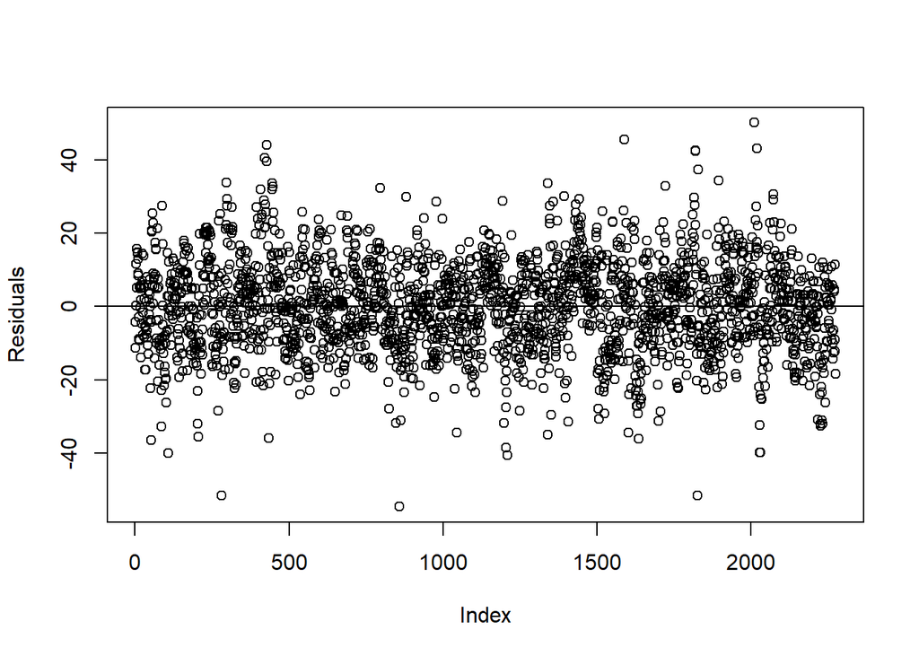

Plotting fitted values against the residuals is more problematic. Although there is no pattern among residuals, there are some outliers and variability does not appear to be constant across the entire range.

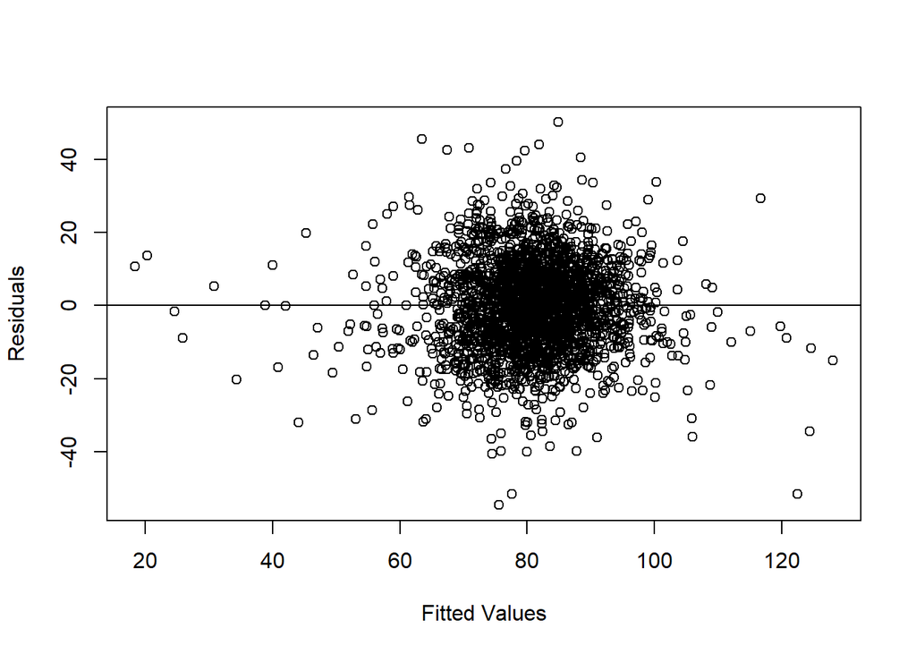

Q-Q plot confirms that residuals are normally distributed.

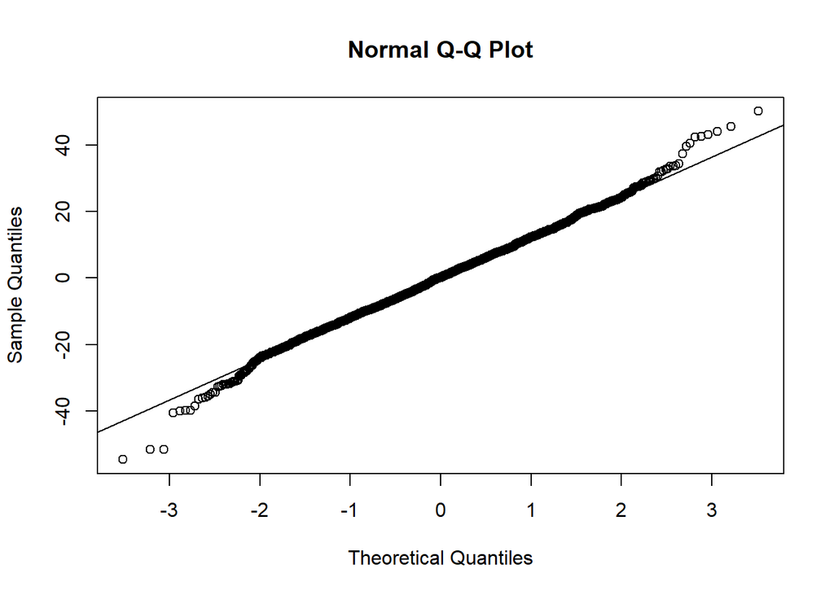

## Prediction

| INDEX | PREDICT_WIN |
| --- | --- |
| 9 | 61 |
| 10 | 64 |
| 14 | 74 |
| 47 | 87 |
| 60 | 69 |
| 63 | 71 |
| 74 | 87 |
| 83 | 76 |
| 98 | 70 |
| 120 | 73 |
| 123 | 67 |
| 135 | 82 |
| 138 | 81 |
| 140 | 83 |
| 151 | 87 |
| 153 | 77 |
| 171 | 74 |
| 184 | 78 |
| 193 | 74 |
| 213 | 90 |
| 217 | 81 |
| 226 | 83 |
| 230 | 80 |
| 241 | 71 |
| 291 | 82 |
| 294 | 88 |
| 300 | 42 |
| 348 | 73 |
| 350 | 83 |
| 357 | 73 |

[output cut: 229 more lines]

## APPENDIX: R Script

```r
# Required libraries
library(dplyr)
library(ggplot2)
library(gridExtra)
library(knitr)
library(kableExtra)
library(Hmisc)

# Import data
bb <- read.csv("moneyball-training-data.csv")

# Basic statistic
nrow(bb); ncol(bb)
summary(bb)

# Get summary table
sumBB = data.frame(Variable = character(),
                   Min = integer(),
                   Median = integer(),
                   Mean = double(),
                   SD = double(),
                   Max = integer(),
                   Num_NAs = integer(),
                   Num_Zeros = integer())

for (i in 2:17) {
  sumBB <- rbind(sumBB, data.frame(Variable = colnames(bb)[i],
                                   Min = min(bb[,i], na.rm=TRUE),
                                   Median = median(bb[,i], na.rm=TRUE),
                                   Mean = mean(bb[,i], na.rm=TRUE),
                                   SD = sd(bb[,i], na.rm=TRUE),
                                   Max = max(bb[,i], na.rm=TRUE),
                                   Num_NAs = sum(is.na(bb[,i])),
                                   Num_Zeros = length(which(bb[,i]==0)))
                 )
}

# Exploratory plots (repeated for each variable)
kable(sumBB[sumBB[,1]=="TEAM_BASERUN_SB",2:8], row.names=FALSE)

# Boxplot
bp <- ggplot(bb, aes(x = 1, y = TEAM_BASERUN_SB)) +
  stat_boxplot(geom ='errorbar') + geom_boxplot() +
  xlab("Boxplot") + ylab("") + theme(axis.text.x=element_blank(), axis.ticks.x=element_blank())

# Density plot
hp <- ggplot(bb, aes(x = TEAM_BASERUN_SB)) +
  geom_histogram(aes(y=..density..), colour="black", fill="white") +
  geom_density(alpha=.2, fill="#FF6666") + ylab("") + xlab("Density Plot with Mean") +
  geom_vline(aes(xintercept=mean(TEAM_BASERUN_SB, na.rm=TRUE)), color="red", linetype="dashed", size=1)

# Scatterplot
sp <- ggplot(data=bb, aes(x=TEAM_BASERUN_SB, y=TARGET_WINS)) +
  geom_point() + geom_smooth(method = "loess") +
  xlab("Scatterplot with Best Fit Line")

grid.arrange(bp, hp, sp, layout_matrix=rbind(c(1,2,2),c(1,3,3)))

# Correlation matrix
cm <- cor(bb, use="pairwise.complete.obs")
cm <- cm[2:17,2:17]
names <- c("Wins", "H", "2B", "3B", "HR", "BB", "SO", "SB", "CS", "HBP", "P-H", "P-HR", "P-BB", "P-SO", "E", "DP")
colnames(cm) <- names; rownames(cm) <- names
cm <- round(cm, 2)
cmout <- as.data.frame(cm) %>% mutate_all(function(x) {
  cell_spec(x, "html", color = ifelse(x>0.5 | x<(-0.5),"blue","black"))
  })
rownames(cmout) <- names
cmout %>%
  kable("html", escape = F, align = "c", row.names = TRUE) %>%
  kable_styling("striped", full_width = F)

bbBackup <- bb

# Remove observations with no target
bb <- bb[which(bb$TARGET_WINS!=0), ]

# Reset zero values
bb[which(bb$TEAM_BATTING_H==0),"TEAM_BATTING_H"] <- NA
bb[which(bb$TEAM_BATTING_2B==0),"TEAM_BATTING_2B"] <- NA
bb[which(bb$TEAM_BATTING_3B==0),"TEAM_BATTING_3B"] <- NA
bb[which(bb$TEAM_BATTING_HR==0),"TEAM_BATTING_HR"] <- NA
bb[which(bb$TEAM_BATTING_BB==0),"TEAM_BATTING_BB"] <- NA
bb[which(bb$TEAM_BATTING_SO==0),"TEAM_BATTING_SO"] <- NA
bb[which(bb$TEAM_BASERUN_SB==0),"TEAM_BASERUN_SB"] <- NA
bb[which(bb$TEAM_BASERUN_CS==0),"TEAM_BASERUN_CS"] <- NA
bb[which(bb$TEAM_FIELDING_E==0),"TEAM_FIELDING_E"] <- NA
bb[which(bb$TEAM_FIELDING_DP==0),"TEAM_FIELDING_DP"] <- NA
bb[which(bb$TEAM_PITCHING_BB==0),"TEAM_PITCHING_BB"] <- NA
bb[which(bb$TEAM_PITCHING_H==0),"TEAM_PITCHING_H"] <- NA
bb[which(bb$TEAM_PITCHING_HR==0),"TEAM_PITCHING_HR"] <- NA
bb[which(bb$TEAM_PITCHING_SO==0),"TEAM_PITCHING_SO"] <- NA

# Impute mimssing values
bbImpute <- aregImpute(~ TARGET_WINS + TEAM_BATTING_H + TEAM_BATTING_2B + TEAM_BATTING_3B +
                         TEAM_BATTING_HR + TEAM_BATTING_BB + TEAM_BATTING_SO + TEAM_BASERUN_SB +
                         TEAM_BASERUN_CS + TEAM_FIELDING_DP + TEAM_FIELDING_E + TEAM_PITCHING_BB +
                         TEAM_PITCHING_H + TEAM_PITCHING_HR + TEAM_PITCHING_SO,
                       data = bb, n.impute = 10)
bbImpute
bbImpute$rsq

bbI <- impute.transcan(bbImpute, imputation=10, data=bb,
                       list.out=TRUE, pr=FALSE, check=FALSE)
bb$TEAM_BASERUN_SB <- bbI$TEAM_BASERUN_SB
bb$TEAM_BASERUN_CS <- bbI$TEAM_BASERUN_CS
bb$TEAM_BATTING_3B <- bbI$TEAM_BATTING_3B
bb$TEAM_BATTING_HR <- bbI$TEAM_BATTING_HR
bb$TEAM_BATTING_SO <- bbI$TEAM_BATTING_SO
bb$TEAM_FIELDING_DP <- bbI$TEAM_FIELDING_DP
bb$TEAM_PITCHING_HR <- bbI$TEAM_PITCHING_HR
bb$TEAM_PITCHING_SO <- bbI$TEAM_PITCHING_SO

# Adjust outliers
bb[which(bb$TEAM_PITCHING_SO>2500),"TEAM_PITCHING_SO"] <- 2500
bb[which(bb$TEAM_PITCHING_H>13000),"TEAM_PITCHING_H"] <- 13000
bb[which(bb$TEAM_PITCHING_BB>1100),"TEAM_PITCHING_BB"] <- 1100

# Creat singles
bb$TEAM_BATTING_S <- bb$TEAM_BATTING_H - bb$TEAM_BATTING_2B - bb$TEAM_BATTING_3B - bb$TEAM_BATTING_HR
summary(bb$TEAM_BATTING_S)

# Create log fielding error
bb$TEAM_FIELDING_E_LOG <- log(bb$TEAM_FIELDING_E)

# Model building
m1 <- lm(TARGET_WINS ~ TEAM_BATTING_H + TEAM_BATTING_BB + TEAM_FIELDING_E, data=bb)
summary(m1)

m2 <- lm(TARGET_WINS ~ TEAM_BATTING_S + TEAM_BATTING_2B + TEAM_BATTING_3B + TEAM_BATTING_HR +
           TEAM_BATTING_BB + TEAM_FIELDING_E, data=bb)
summary(m2)
m2b <- lm(TARGET_WINS ~ TEAM_BATTING_S + TEAM_BATTING_2B + TEAM_BATTING_3B + TEAM_BATTING_HR +
           TEAM_BATTING_BB + TEAM_FIELDING_E_LOG, data=bb)
summary(m2b)

m3 <- lm(TARGET_WINS ~ TEAM_BATTING_SO:TEAM_BATTING_H + TEAM_BATTING_BB:TEAM_BATTING_H + TEAM_BATTING_SO +
           TEAM_BASERUN_SB + TEAM_FIELDING_DP + TEAM_PITCHING_HR + TEAM_FIELDING_E_LOG, data=bb)
summary(m3)

m4 <- lm(TARGET_WINS ~ TEAM_BATTING_S + TEAM_BATTING_2B + TEAM_BATTING_3B +
           TEAM_BATTING_HR + TEAM_BATTING_BB + TEAM_BATTING_SO + TEAM_BASERUN_SB +
           TEAM_BASERUN_CS + TEAM_FIELDING_DP + TEAM_FIELDING_E + TEAM_PITCHING_BB +
           TEAM_PITCHING_H + TEAM_PITCHING_SO + TEAM_PITCHING_HR, data=bb)
summary(m4)
m4 <- lm(TARGET_WINS ~ TEAM_BATTING_S + TEAM_BATTING_2B + TEAM_BATTING_3B +
           TEAM_BATTING_HR + TEAM_BATTING_BB + TEAM_BATTING_SO + TEAM_BASERUN_SB +
           TEAM_FIELDING_DP + TEAM_FIELDING_E + TEAM_PITCHING_BB +
           TEAM_PITCHING_H + TEAM_PITCHING_SO + TEAM_PITCHING_HR, data=bb)
summary(m4)

m5 <- lm(TARGET_WINS ~ TEAM_BATTING_S  + TEAM_BATTING_3B +
           TEAM_BATTING_HR + TEAM_BASERUN_SB  +
           TEAM_FIELDING_E_LOG*TEAM_PITCHING_H, data=bb)
summary(m5)

# Residuals plots
plot(m4$residuals, ylab="Residuals")
abline(h=0)

plot(m4$fitted.values, m4$residuals, xlab="Fitted Values", ylab="Residuals")
abline(h=0)

qqnorm(m4$residuals)
qqline(m4$residuals)

# Test data for prediction
bbTest <- read.csv("moneyball-evaluation-data.csv")

bbTest[which(bbTest$TEAM_BATTING_H==0),"TEAM_BATTING_H"] <- NA
bbTest[which(bbTest$TEAM_BATTING_2B==0),"TEAM_BATTING_2B"] <- NA
bbTest[which(bbTest$TEAM_BATTING_3B==0),"TEAM_BATTING_3B"] <- NA
bbTest[which(bbTest$TEAM_BATTING_HR==0),"TEAM_BATTING_HR"] <- NA
bbTest[which(bbTest$TEAM_BATTING_BB==0),"TEAM_BATTING_BB"] <- NA
bbTest[which(bbTest$TEAM_BATTING_SO==0),"TEAM_BATTING_SO"] <- NA
bbTest[which(bbTest$TEAM_BASERUN_SB==0),"TEAM_BASERUN_SB"] <- NA
bbTest[which(bbTest$TEAM_BASERUN_CS==0),"TEAM_BASERUN_CS"] <- NA
bbTest[which(bbTest$TEAM_FIELDING_E==0),"TEAM_FIELDING_E"] <- NA
bbTest[which(bbTest$TEAM_FIELDING_DP==0),"TEAM_FIELDING_DP"] <- NA
bbTest[which(bbTest$TEAM_PITCHING_BB==0),"TEAM_PITCHING_BB"] <- NA
bbTest[which(bbTest$TEAM_PITCHING_H==0),"TEAM_PITCHING_H"] <- NA
bbTest[which(bbTest$TEAM_PITCHING_HR==0),"TEAM_PITCHING_HR"] <- NA
bbTest[which(bbTest$TEAM_PITCHING_SO==0),"TEAM_PITCHING_SO"] <- NA

# Impute mimssing values
bbImpute <- aregImpute(~ TEAM_BATTING_H + TEAM_BATTING_2B + TEAM_BATTING_3B +
                         TEAM_BATTING_HR + TEAM_BATTING_BB + TEAM_BATTING_SO + TEAM_BASERUN_SB +
                         TEAM_BASERUN_CS + TEAM_FIELDING_DP + TEAM_FIELDING_E + TEAM_PITCHING_BB +
                         TEAM_PITCHING_H + TEAM_PITCHING_HR + TEAM_PITCHING_SO,
                       data = bbTest, n.impute = 10)
bbImpute
bbImpute$rsq

bbI <- impute.transcan(bbImpute, imputation=10, data=bbTest,
                       list.out=TRUE, pr=FALSE, check=FALSE)
bbTest$TEAM_BATTING_HR <- bbI$TEAM_BATTING_HR
bbTest$TEAM_BATTING_SO <- bbI$TEAM_BATTING_SO
bbTest$TEAM_BASERUN_SB <- bbI$TEAM_BASERUN_SB
bbTest$TEAM_BASERUN_CS <- bbI$TEAM_BASERUN_CS
bbTest$TEAM_FIELDING_DP <- bbI$TEAM_FIELDING_DP
bbTest$TEAM_PITCHING_HR <- bbI$TEAM_PITCHING_HR
bbTest$TEAM_PITCHING_SO <- bbI$TEAM_PITCHING_SO

# Adjust outliers
bbTest[which(bbTest$TEAM_PITCHING_SO>2500),"TEAM_PITCHING_SO"] <- 2500
bbTest[which(bbTest$TEAM_PITCHING_H>13000),"TEAM_PITCHING_H"] <- 13000
bbTest[which(bbTest$TEAM_PITCHING_BB>1100),"TEAM_PITCHING_BB"] <- 1100

bbTest$TEAM_BATTING_S <- bbTest$TEAM_BATTING_H - bbTest$TEAM_BATTING_2B - bbTest$TEAM_BATTING_3B - bbTest$TEAM_BATTING_HR

bbTest$PREDICT_WIN <- predict(m4, newdata=bbTest, interval="confidence")

round(bbTest[, c(1,18)],0)
```